# Exposure and confidence

October 21, 2016, Hopkins Marine Station, Stanford University

## Exposure and confidence

- **My origins in programming, data science, and open science**
- **Improving reproducibility, collaboration and communication in environmental science with open science tools**
- **Resources and recommendations**

## Reproducibility

Reproducibility is foundatational to science, but we rarely test it, even with our own work.

## Data science and open science

**Data Science**:

"an exciting discipline that allows you to turn raw data into understanding, insight, and knowledge" ([*Grolemund & Wickham 2016*](http://r4ds.had.co.nz/))

## Data science and open science

**Data Science**:

"an exciting discipline that allows you to turn raw data into understanding, insight, and knowledge" ([*Grolemund & Wickham 2016*](http://r4ds.had.co.nz/))

## Data science and open science

**Data Science**:

"an exciting discipline that allows you to turn raw data into understanding, insight, and knowledge" ([*Grolemund & Wickham 2016*](http://r4ds.had.co.nz/))

**Open Science**:

"the concept of transparency at all stages of the research process, coupled with free and open access to data, code, and papers" ([*Hampton et al. 2014*](http://onlinelibrary.wiley.com/doi/10.1890/ES14-00402.1/full))

## Data science and open science tools

I primarily use these tools:

- [**R**](https://cran.r-project.org/)
- [**RStudio**](https://www.rstudio.com/)
- [**git**](https://git-scm.com/)
- [**GitHub**](https://www.github.com/)

This talk: jules32.github.io/opensci-talk

## My origins story

[figure not shown]

## Some thesis questions

- what are Humboldt squid habitat preferences?
- what season are they most abundant?
- how fast and far can they migrate?
- how do they interact with other species?
- how do I import my data when it's too big for Excel?
- how do I subset years or other attributes?
- how on earth do I visualize any of this?

## Conflated questions

**Science:**

- what are their habitat preferences?
- what season are they most abundant?
- how fast and far can they migrate?
- how do they interact with other species?

**Data science:**

- how do I import my data when it's too big for Excel?
- how do I subset years or other attributes?
- how on earth do I visualize any of this?

## I learned to program like many do

- in a panic
- for a single purpose (get this thesis done!)
- in near-isolation*

## I learned to program like many do

- in a panic
- for a single purpose (get this thesis done!)
- in near-isolation*

* Thankfully, I had wonderful programming mentors:

Steve Haddock, Dave Foley, Ashley Booth

## Ocean Health Index

- method to categorize benefits that oceans provide to people
- scores are modeled using existing data
- method can be tailored to different geographies
- can help inform policy decisions, especially when repeated

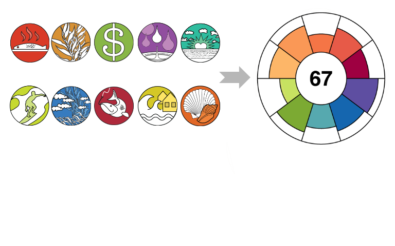

## OHI Global Assessments

**2012: OHI method and first global assessment** ([*Halpern et al. 2012*](http://www.nature.com/nature/journal/v488/n7413/abs/nature11397.html))

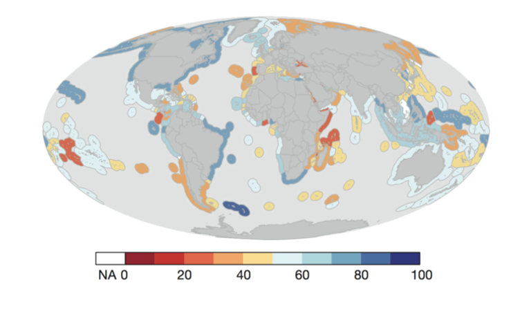

## OHI Global Assessments

**2013: second annual global assessment**

- repeat methods
- update data
- compare between years

## OHI Global Assessments

**2013: second annual global assessment**

- repeat methods
- update data
- compare between years

We expected to easily reproduce our previous work. We had planned ahead:

- coded models
- 130 pages of published supplemental material
- internal documents and notes

## We thought we were doing reproducible science

We struggled to reproduce our work using standard approaches to reproducibility and collaboration

- added challenge of managing multiple years of information and scores
- we needed a nimble approach to sharing data, methods, and results within and outside our team

*Lowndes et al. in prep: Improving reproducibility, collaboration, and communication in environmental science using open science tools*

underscore the importance of:

- exposure and confidence
- evolution rather than revolution

## We identified three main challenges to overcome

1. **reproducibility**, including transparency and repeatability, particularly in data preparation
2. **collaboration**, including teamwork and internal collaboration
3. **communication** with scientific and public communities

## Addressing challenges using open science tools

[figure not shown]

## Reproducibility - data preparation

*"Data scientists, according to interviews and expert estimates, spend from 50 percent to 80 percent of their time mired in the mundane labor of collecting and preparing data, before it can be explored for useful information." - [NYTimes (2014)](http://www.nytimes.com/2014/08/18/technology/for-big-data-scientists-hurdle-to-insights-is-janitor-work.html)*

- transforming, rescaling, gap-filling, formatting, etc
- seldom mentioned but underpins the scientific process

## Reproducibility - data preparation

*"Data scientists, according to interviews and expert estimates, spend from 50 percent to 80 percent of their time mired in the mundane labor of collecting and preparing data, before it can be explored for useful information." - [NYTimes (2014)](http://www.nytimes.com/2014/08/18/technology/for-big-data-scientists-hurdle-to-insights-is-janitor-work.html)*

- transforming, rescaling, gap-filling, formatting, etc
- seldom mentioned but underpins the scientific process

Ultimate goal: **Tidy data** *([Wickham 2014](https://www.jstatsoft.org/article/view/v059i10))*

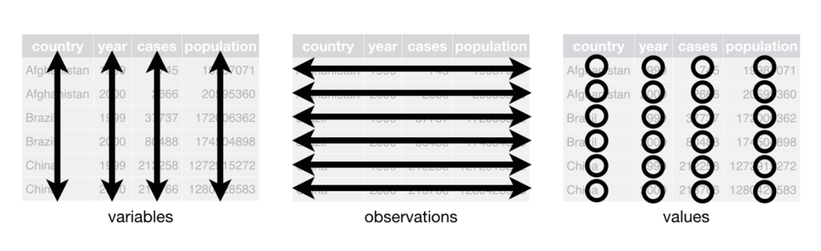

## Reproducibility - data preparation

[figure not shown]

## Reproducibility - data preparation

**Before**

- manually (without coding)
- largely Microsoft Excel
- internal documents and emails

**After**

- full process coded
  - R with documentation
  - RMarkdown

## Reproducibility - data preparation

Data wrangling with the grammar of data manipulation and tidy data  
[Grolemund & Wickham 2016: *R for Data Science*](http://r4ds.had.co.nz/tidy-data.html#spreading-and-gathering)

[figure not shown]

## Reproducibility - version control

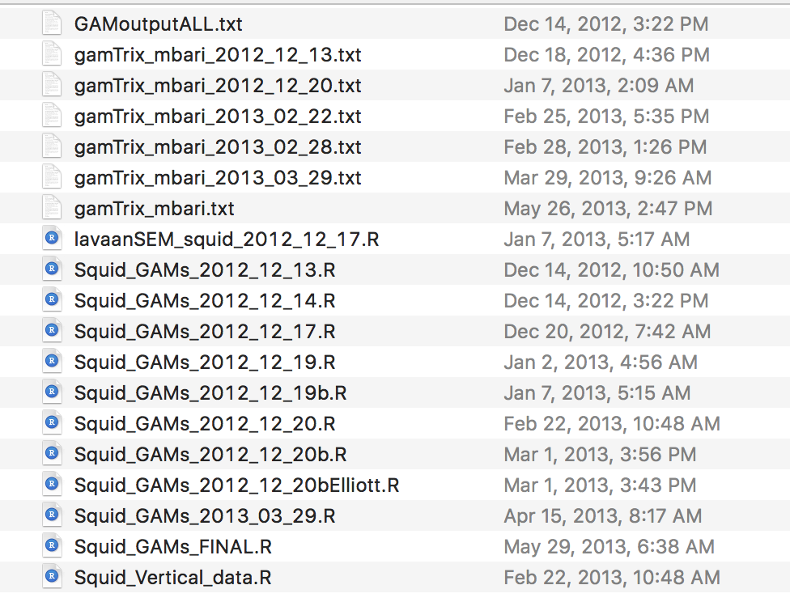

## Reproducibility - version control

**Before**

- filenames suffixed with dates, initials (e.g. `final.csv` and `final_JL-2016-08-05.csv`)
- email descriptions of what changed between files

**After**

- version control with `git`
- short messages accompany commited changes

## Collaboration

[figure not shown]

## Collaboration

**Before**

- team structure: scientists and single programmer
- discrete tasks:
  - scientists developed the models conceptually, gathered data, prepared data, interpreted modeled results
  - programmer coded the models.
- communication + file sharing: email chains (often forwarded).
- organization: individual conventions on local computers

Redesigning our team's workflow required a substantial time investment to learn the tools, and a paradigm shift in our approach to collaboration. Previous to this investment, most team members with any coding experience had learned just enough to accomplish specific tasks (not necessarily in R), and had developed unique conventions. Given the complexity of the project, we needed to learn to code collaboratively and incorporate best practices into our coding25 so that methods for data preparation and modeling could be co-developed and vetted by multiple team members. Further, using a version control system allowed individuals to feel less inhibited about their coding contributions, since files could always be reverted back to previous versions if there were problems.

## OHI Today

with these efforts, we now have 26 countries interested

demo http://ohi-science.org/

Training (incl. Software Carpentry)

## My recommendations

**Introduce these concepts incrementally: evolution not revolution**

**1 - Learn to code; script your work**

- in R  
- with RStudio

**2 - Use version control**

- git  
- with GitHub  
- through RStudio

Things that helped me:

http://ohi-science.org/news/Resources-for-R-and-Data-Science

## Becoming a data scientist

[figure not shown]

## Demos of Main tools

- R and RStudio for coding and visualization
- Git for version control, [GitHub](https://github.com) for collaboration
- GitHub + RStudio for organization, documentation, online publishing, distribution, and communication [ohi-science.org](http://ohi-science.org/)

## Extra slides

## Improving using open science tools

**reproducibility**

- data preparation: coding and documenting
- modeling: `R` functions and packages
- version control
- organization

**collaboration**

- teamwork
- (simplified) GitHub workflow

**communication**

- sharing data and code
- sharing methods and instruction

## My origins in programming and data science

- as a grad student I learned due to panic
- just needed to get the job done
- PCfB
- resistant to version control

## WSN plug

15-minute version of this talk:

Friday, Nov 11

Session 7 'Windjammer' room